# Lasso vs. Ridge

Yongqi Liang

We discussed lasso and ridge regressions in the last lecture. In this lab, we use simulated datasets to fit these models and compare their performances to illustrate when one works better.

## Task 1: Generate simulated data sets

To understand how a statistical learning method works, it is important to simulate a mock-up dataset where you know the underlying structure, so that you can use the dataset to examine and validate the behaviour of a model.

#### Step 1.1: Generate the data sets

Run the following code chunk. As a warm-up, what do you expect the output would be when you run `lm(Y~., data = dat_A)`?

I would expect that all the variables will have a coefficient.

```r
# load libraries
library(glmnet)
library(MASS)
library(tidyverse)
# set up parameters
set.seed(1)
n <- 90
p <- 90
lambdas <- 2^ seq(6, -4, length = 100)  # lambda values.
# set up correlation matrix between Xs.
corr <- 0.75
cor.mat <- matrix(corr, nrow = p, ncol = p)
diag(cor.mat) <- 1
cor.mat[lower.tri(cor.mat)] <- t(cor.mat)[lower.tri(cor.mat)]
# dat_A
X1 <- mvrnorm(n, mu=rep(1, p), Sigma = cor.mat)
colnames(X1) <- paste0('X', str_pad(1:p, nchar(p), 'left', '0'))
n_betas <- 5
betas <- as.vector(scale(sample(1:n_betas))) * 10
related.ind <- sample(1:p, n_betas)
y1 <- as.numeric(betas %*% t(X1[,related.ind]) + rnorm(n))
dat_A <- cbind(data.frame(Y = y1), X1)

# dat_B
X2 <- mvrnorm(n, mu=rep(1, p), Sigma = cor.mat)
colnames(X2) <- paste0('X', str_pad(1:p, nchar(p), 'left', '0'))
all_betas <- sample(as.vector(scale(1:p))) * 0.1
y2 <- as.numeric(all_betas %*% t(X2) + rnorm(n))
dat_B <- cbind(data.frame(Y = y2), X2)

lm(Y~., data = dat_A)
```

```
##
## Call:
## lm(formula = Y ~ ., data = dat_A)
##
## Coefficients:
## (Intercept)          X01          X02          X03          X04          X05
##    -6.45382      2.73289     -0.20959      1.97319      3.03946      7.67820
##         X06          X07          X08          X09          X10          X11
##    -1.85611      6.54850     -2.06875     -1.16041     10.55018      1.28233
##         X12          X13          X14          X15          X16          X17
##   -10.26757     -7.94736      1.01612      3.56459     -1.40759      0.38274
##         X18          X19          X20          X21          X22          X23
##     3.66716      1.08147     19.12030    -11.86096      7.20137     -0.01433
##         X24          X25          X26          X27          X28          X29
##    -0.16766      7.65392      4.52243     -6.35037      6.57084     -8.44642
##         X30          X31          X32          X33          X34          X35
##    11.00211      1.45552     -2.73419      1.75210     -4.58089     -7.69919
##         X36          X37          X38          X39          X40          X41
##     3.61717     -2.11779    -18.55389      2.27350     -0.63707     -8.73424
##         X42          X43          X44          X45          X46          X47
##     6.52319      2.34280    -10.65800      4.45598      4.13715      3.01433
##         X48          X49          X50          X51          X52          X53
##    -9.12858     -2.93661      1.23335      3.06136      2.56349     -8.71091
##         X54          X55          X56          X57          X58          X59
##     7.56710      4.85437     -8.43423    -13.48312      1.42658      4.73787
##         X60          X61          X62          X63          X64          X65
##     3.95088     -3.03326      0.40297     -3.43985     -5.46868     -0.41170
##         X66          X67          X68          X69          X70          X71
##    -0.78413     -1.53752     -8.71996      4.94733      2.80653      1.22205
##         X72          X73          X74          X75          X76          X77
##     0.49547     -2.35459      0.07041      4.76618      3.71687      2.17946
##         X78          X79          X80          X81          X82          X83
##     1.47513      0.53029     -2.49796      4.41774     -4.15726      0.59538
##         X84          X85          X86          X87          X88          X89
##    -5.83416     -6.50221      3.18289      0.77792      4.06513      3.81675
##         X90
##          NA
```

#### Step 1.2: Understand the code

Examine the code chunk from 1.1 above, what is the similarity and difference between the two data sets, `dat_A` and `dat_B`?

They both have 90 rows and 90 explanatory variables.

#### Step 1.3: Split into `train` and `test`

Split each one of the data sets into training (80%) and test (20%) sets. You should have `train_A`, `test_A`, `train_B`, and `test_B` by the end of this step.

```r
#dat_A
t_num <- nrow(dat_A) * 0.8
my_sample<-sample(nrow(dat_A), t_num)
train_A <- dat_A[my_sample,]
test_A <- dat_A[-my_sample,]

#dat_B
t_num <- nrow(dat_B) * 0.8
my_sample<-sample(nrow(dat_B), t_num)
train_B <- dat_B[my_sample,]
test_B <- dat_B[-my_sample,]
```

## Task 2: Fit lasso regression

For each one of the data sets, do following:

1. fit a lasso model on the training set, with $\lambda$ chosen by cross-validation.
2. Calculate the test MSPE, and the number of non-zero coefficient estimates from the optimal model (i.e. the model with the optimal $\lambda$ chosen above by cross-validation).

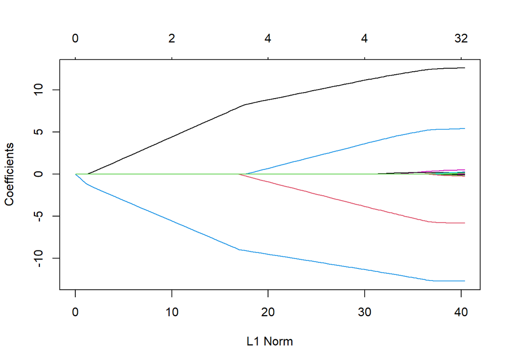

```r
# A
library(glmnet)
X<-as.matrix(train_A[,-1])
y<-train_A$Y
set.seed(107)
fit <-glmnet(X,y)
plot(fit)
```

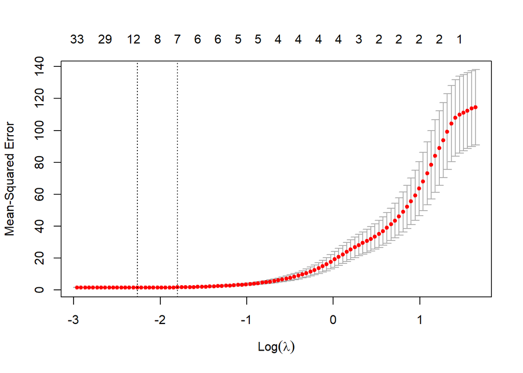

```r
xval <-cv.glmnet(X,y)
plot(xval)
```

The test MSPE for dat_A

```r
Xtest<-as.matrix(test_A[,-1])
predy<-predict(fit, Xtest, s=xval$lambda.min)
MSPE_A= sum((test_A$Y - predy)^2) / nrow(Xtest)
MSPE_A
```

```
## [1] 1.928864
```

The number of non-zero coefficient estimates from the optimal model for dat_A

```r
coef(fit, s=xval$lambda.min)
```

```
## 91 x 1 sparse Matrix of class "dgCMatrix"
##                        s1
## (Intercept)  -0.029829964
## X01           .
## X02           .
## X03           .
## X04           .
## X05           .
## X06           .
## X07           .
## X08           0.080492394
## X09           .
## X10          -0.045795374
## X11           .
## X12           .
## X13           .
## X14           .
## X15           .
## X16           0.341313473
## X17           .
## X18           .
## X19           .
## X20          12.490034481
## X21           0.061374792
## X22           .
## X23           .
## X24           .
## X25           .
## X26           .
## X27           .
## X28           .
## X29           .
## X30           0.001454525
## X31           .
## X32           .
## X33           .
## X34           .
## X35          -0.047316840
## X36           .
## X37           .
```

[output cut: 38 more lines]

```
## X76           .
## X77           .
## X78           .
## X79           0.034212251
## X80           .
## X81           .
## X82           .
## X83           .
## X84           .
## X85          -5.698094561
## X86           .
## X87           .
## X88           .
## X89           .
## X90           .
```

```r
sum(coef(fit, s=xval$lambda.min) != 0)-1
```

```
## [1] 12
```

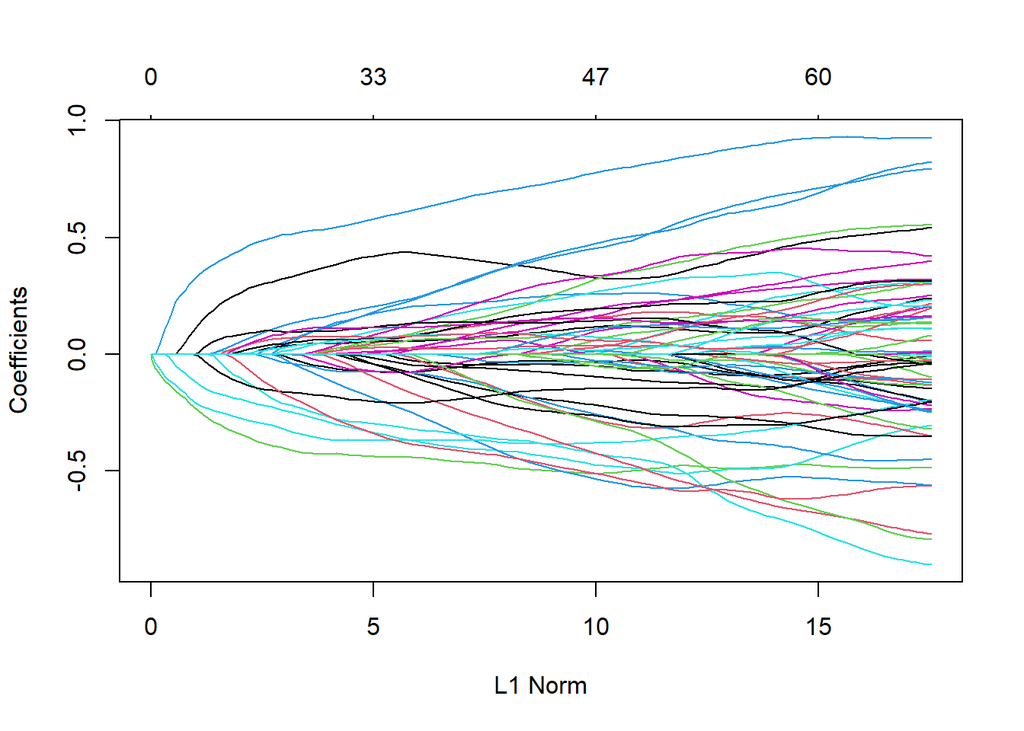

```r
# B
library(glmnet)
X<-as.matrix(train_B[,-1])
y<-train_B$Y
set.seed(107)
fit <-glmnet(X,y)
plot(fit)
```

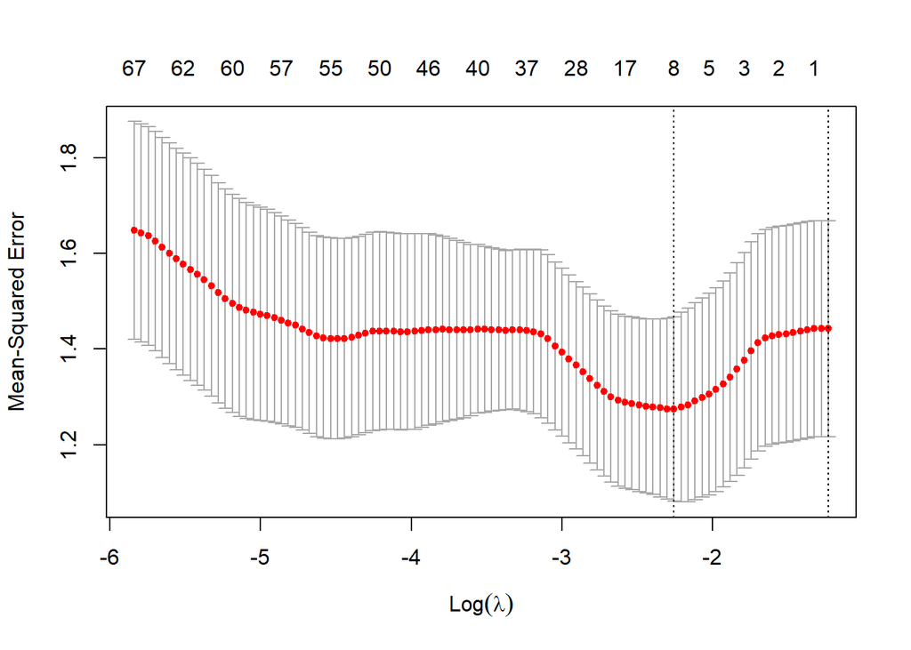

```r
xval <-cv.glmnet(X,y)
plot(xval)
```

The test MSPE for dat_B

```r
Xtest<-as.matrix(test_B[,-1])
predy<-predict(fit, Xtest, s=xval$lambda.min)
MSPE_B= sum((test_B$Y - predy)^2) / nrow(Xtest)
MSPE_B
```

```
## [1] 1.170679
```

The number of non-zero coefficient estimates from the optimal model for dat_B

```r
coef(fit, s=xval$lambda.min)
```

```
## 91 x 1 sparse Matrix of class "dgCMatrix"
##                        s1
## (Intercept)  0.2705699613
## X01          .
## X02          .
## X03          .
## X04         -0.2740197337
## X05          .
## X06         -0.1521102899
## X07          .
## X08          0.1721442308
## X09          .
## X10          .
## X11          .
## X12          .
## X13          .
## X14          .
## X15          .
## X16          0.0003978324
## X17          .
## X18          .
## X19          .
## X20          .
## X21          .
## X22          .
## X23          .
## X24          .
## X25          .
## X26          .
## X27          .
## X28          .
## X29          .
## X30          .
## X31          .
## X32          .
## X33          .
## X34          .
## X35          .
## X36          .
## X37          .
```

[output cut: 38 more lines]

```
## X76          .
## X77          .
## X78          .
## X79          .
## X80          .
## X81          .
## X82          .
## X83          .
## X84          .
## X85          .
## X86         -0.0417634319
## X87          .
## X88          .
## X89          0.3713731179
## X90          .
```

```r
sum(coef(fit, s=xval$lambda.min) != 0)-1
```

```
## [1] 8
```

## Task 3: Fit ridge regression

For each one of the data sets, do following:

1. fit a ridge model on the training set, with $\lambda$ chosen by cross-validation.
2. Calculate the test MSPE, and the number of non-zero coefficient estimates from the optimal model.

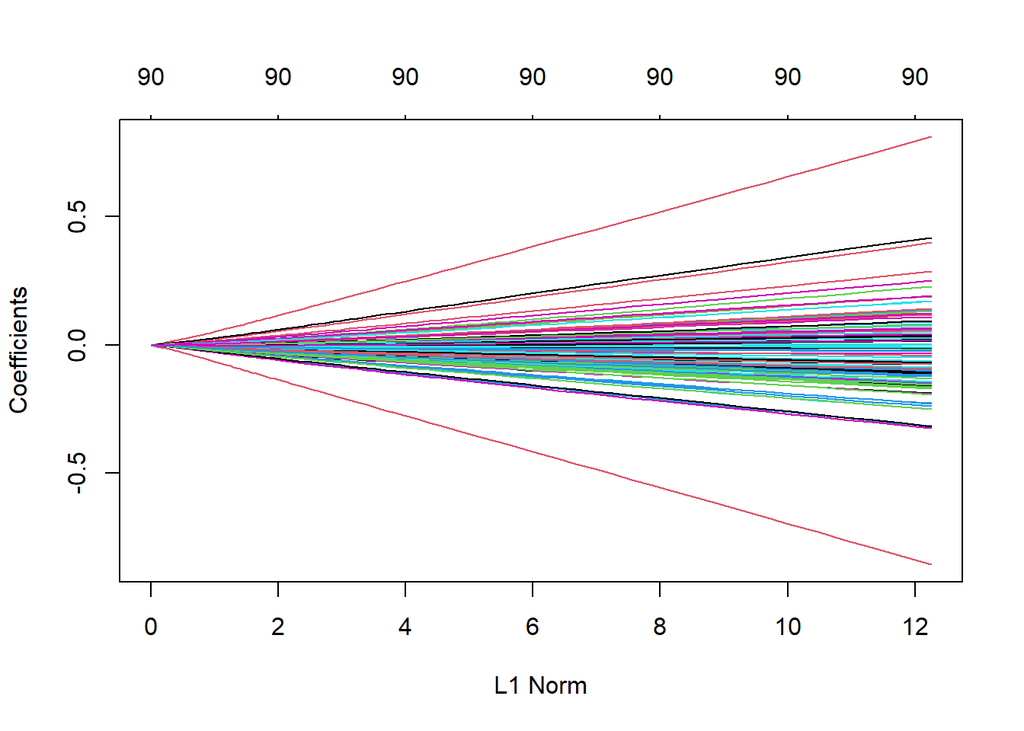

```r
# A
library(glmnet)
X<-as.matrix(train_A[,-1])
y<-train_A$Y
set.seed(107)
fit <-glmnet(X,y, alpha = 0) # alpha = 0 --> ridge penalty
plot(fit)
```

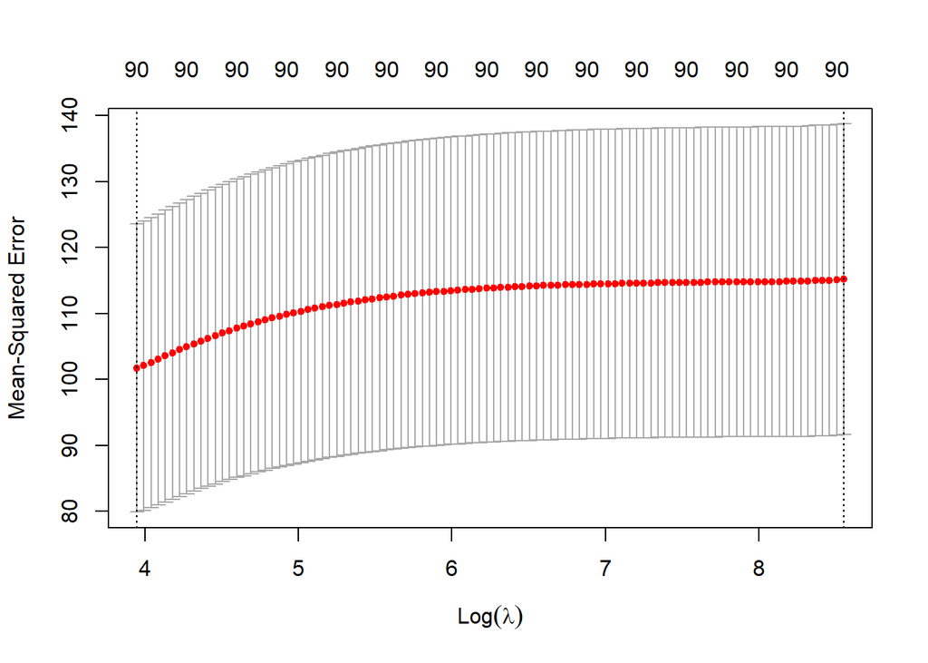

```r
xval <-cv.glmnet(X,y, alpha = 0) # alpha = 0 --> ridge penalty
plot(xval)
```

The test MSPE for dat_A

```r
Xtest<-as.matrix(test_A[,-1])
predy<-predict(fit, Xtest, s=xval$lambda.min)
MSPE_A= sum((test_A$Y - predy)^2) / nrow(Xtest)
MSPE_A
```

```
## [1] 71.41436
```

The number of non-zero coefficient estimates from the optimal model for dat_A

```r
coef(fit, s=xval$lambda.min)
```

```
## 91 x 1 sparse Matrix of class "dgCMatrix"
##                       s1
## (Intercept) -0.157171187
## X01         -0.106436242
## X02          0.399593793
## X03         -0.014732768
## X04          0.120370617
## X05         -0.086879808
## X06         -0.034537279
## X07         -0.187941768
## X08          0.064290165
## X09          0.190587788
## X10         -0.099187518
## X11         -0.063537468
## X12         -0.024397577
## X13         -0.076180728
## X14          0.189681830
## X15          0.133235013
## X16          0.135673663
## X17         -0.090448556
## X18         -0.145729283
## X19         -0.160458847
## X20          0.811623315
## X21          0.131339242
## X22         -0.240248790
## X23          0.077443124
## X24          0.014592491
## X25         -0.012186737
## X26          0.043431750
## X27         -0.170486815
## X28         -0.230447404
## X29          0.003093606
## X30          0.066511544
## X31          0.019976258
## X32          0.059017831
## X33          0.036681996
## X34         -0.076075779
## X35         -0.251169576
## X36         -0.074293712
## X37          0.418344646
```

[output cut: 38 more lines]

```
## X76         -0.118046967
## X77         -0.050230527
## X78          0.190890324
## X79          0.094556502
## X80         -0.094388784
## X81          0.082011079
## X82         -0.024862567
## X83          0.027429821
## X84          0.016039602
## X85         -0.317907589
## X86         -0.075252587
## X87         -0.249944227
## X88         -0.123236229
## X89          0.170538216
## X90          0.122667444
```

```r
sum(coef(fit, s=xval$lambda.min) != 0)-1
```

```
## [1] 90
```

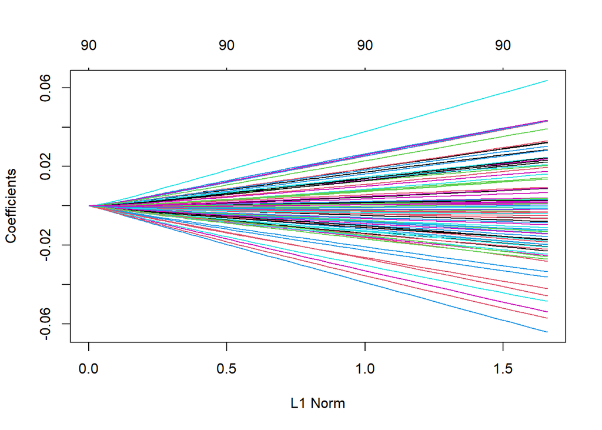

```r
# B
library(glmnet)
X<-as.matrix(train_B[,-1])
y<-train_B$Y
set.seed(107)
fit <-glmnet(X,y, alpha = 0) # alpha = 0 --> ridge penalty
plot(fit)
```

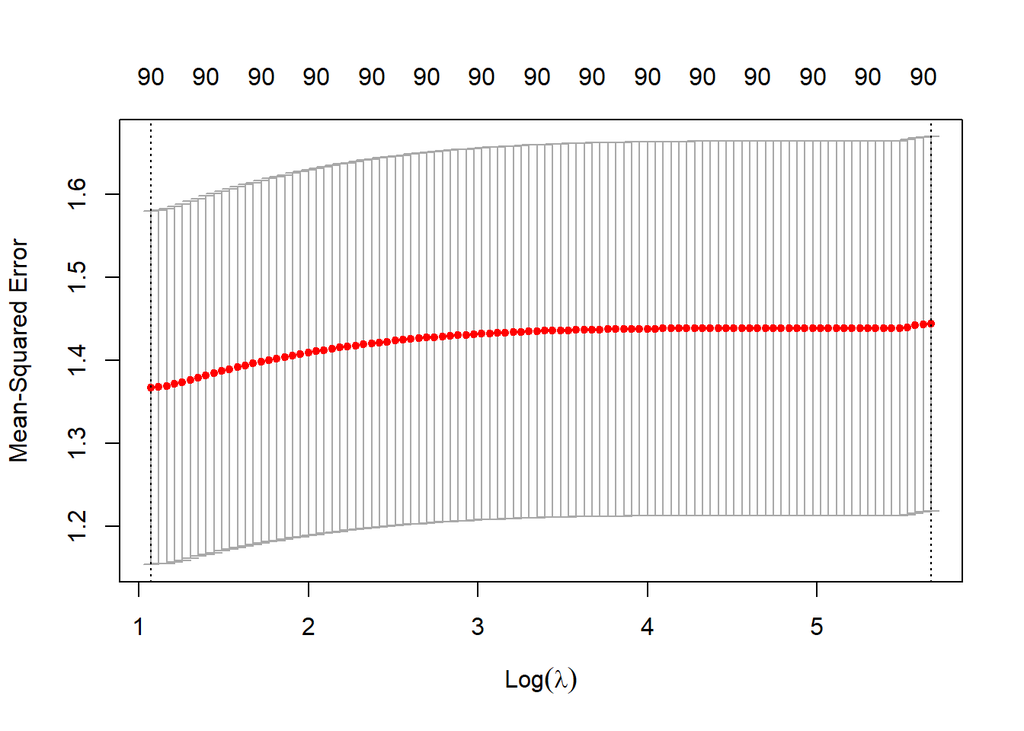

```r
xval <-cv.glmnet(X,y, alpha = 0) # alpha = 0 --> ridge penalty
plot(xval)
```

The test MSPE for dat_B

```r
Xtest<-as.matrix(test_B[,-1])
predy<-predict(fit, Xtest, s=xval$lambda.min)
MSPE_B= sum((test_B$Y - predy)^2) / nrow(Xtest)
MSPE_B
```

```
## [1] 1.293752
```

The number of non-zero coefficient estimates from the optimal model for dat_B

```r
coef(fit, s=xval$lambda.min)
```

```
## 91 x 1 sparse Matrix of class "dgCMatrix"
##                        s1
## (Intercept)  0.2321571583
## X01         -0.0207738595
## X02          0.0196320158
## X03         -0.0033521069
## X04         -0.0642225940
## X05          0.0162569744
## X06         -0.0539235364
## X07          0.0285873579
## X08          0.0430026270
## X09          0.0010351968
## X10         -0.0155798489
## X11         -0.0196250778
## X12          0.0040415321
## X13          0.0029496759
## X14         -0.0280918773
## X15         -0.0030386244
## X16          0.0435023800
## X17         -0.0110270194
## X18          0.0026064506
## X19          0.0321147477
## X20         -0.0039645436
## X21          0.0137701598
## X22          0.0034925012
## X23          0.0035108195
## X24         -0.0018198390
## X25          0.0088594020
## X26          0.0093845104
## X27          0.0039447551
## X28         -0.0197559072
## X29         -0.0128588780
## X30         -0.0252754792
## X31          0.0324504127
## X32         -0.0457732802
## X33         -0.0006290193
## X34         -0.0334650648
## X35         -0.0005641912
## X36          0.0240170772
## X37          0.0029197295
```

[output cut: 38 more lines]

```
## X76         -0.0086934131
## X77         -0.0244990708
## X78          0.0436285478
## X79         -0.0169510345
## X80         -0.0221478395
## X81          0.0393155473
## X82         -0.0122075985
## X83         -0.0040230080
## X84         -0.0141842225
## X85          0.0244301873
## X86         -0.0419959198
## X87         -0.0258910982
## X88          0.0003859424
## X89          0.0637468388
## X90          0.0175318421
```

```r
sum(coef(fit, s=xval$lambda.min) != 0)-1
```

```
## [1] 90
```

## Task 4: Compare and comment

Compare all the results from above (that is, two models for each of the two data sets), and comment on their performance.

For both data sets, all the variables have coefficient when fitting the ridge model. While the lasso model for both data sets only have about 10 variables have coefficients.